# Udacity 651 PS4

Problem set 4

Getting started

```r
library(ggplot2)
library(dplyr)
setwd("~/projects/Classes/FoundationsOfDataScience_sliderule/github/UD651/L4")
data(diamonds)
```

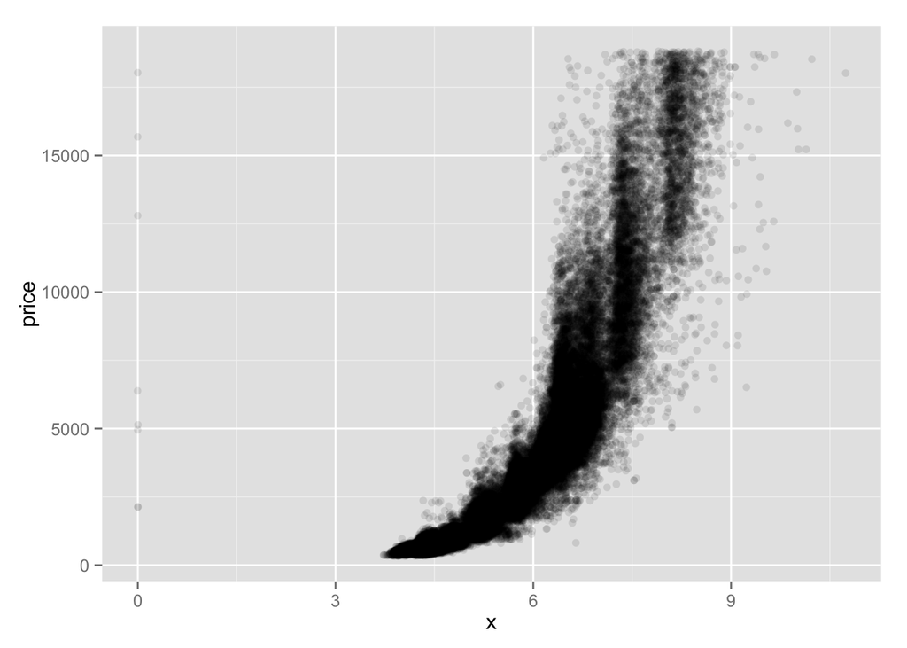

```r
ggplot(aes(x = x, y = price), data = diamonds) +
  geom_jitter(alpha = 1/10)
```

#### What are your observations about the scatterplot of price vs. x?

Response:

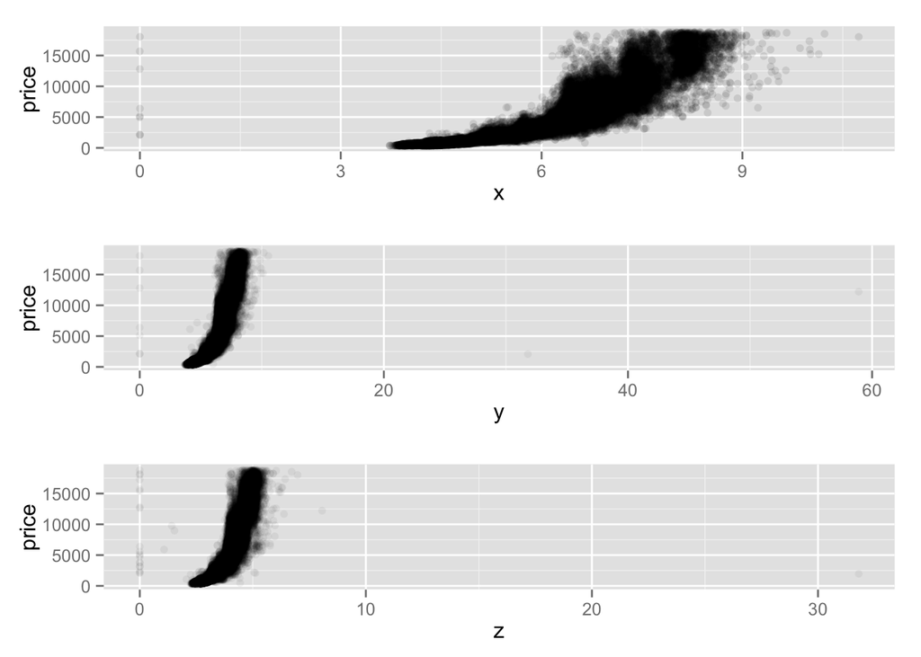

```r
library(gridExtra)
p1 = ggplot(aes(x = x, y = price), data = diamonds) +
  geom_jitter(alpha = 1/10)

p2 = ggplot(aes(x = y, y = price), data = diamonds) +
  geom_jitter(alpha = 1/20)

p3 = ggplot(aes(x = z, y = price), data = diamonds) +
  geom_jitter(alpha = 1/20)

grid.arrange(p1, p2, p3, ncol = 1)
```

```r
with(diamonds, cor.test(x, price))
```

```
##
##  Pearson's product-moment correlation
##
## data:  x and price
## t = 440.16, df = 53938, p-value < 2.2e-16
## alternative hypothesis: true correlation is not equal to 0
## 95 percent confidence interval:
##  0.8825835 0.8862594
## sample estimates:
##       cor
## 0.8844352
```

```r
with(diamonds, cor.test(y, price))
```

```
##
##  Pearson's product-moment correlation
##
## data:  y and price
## t = 401.14, df = 53938, p-value < 2.2e-16
## alternative hypothesis: true correlation is not equal to 0
## 95 percent confidence interval:
##  0.8632867 0.8675241
## sample estimates:
##       cor
## 0.8654209
```

```r
with(diamonds, cor.test(z, price))
```

```
##
##  Pearson's product-moment correlation
##
## data:  z and price
## t = 393.6, df = 53938, p-value < 2.2e-16
## alternative hypothesis: true correlation is not equal to 0
## 95 percent confidence interval:
##  0.8590541 0.8634131
## sample estimates:
##       cor
## 0.8612494
```

#### What is the correlation …

#### between price and x?

Response:

positive, exponential 0.88

#### between price and y?

Response:

positive, exponential 0.87

#### between price and z?

Response:

positive, exponential 0.86

### price vs. depth

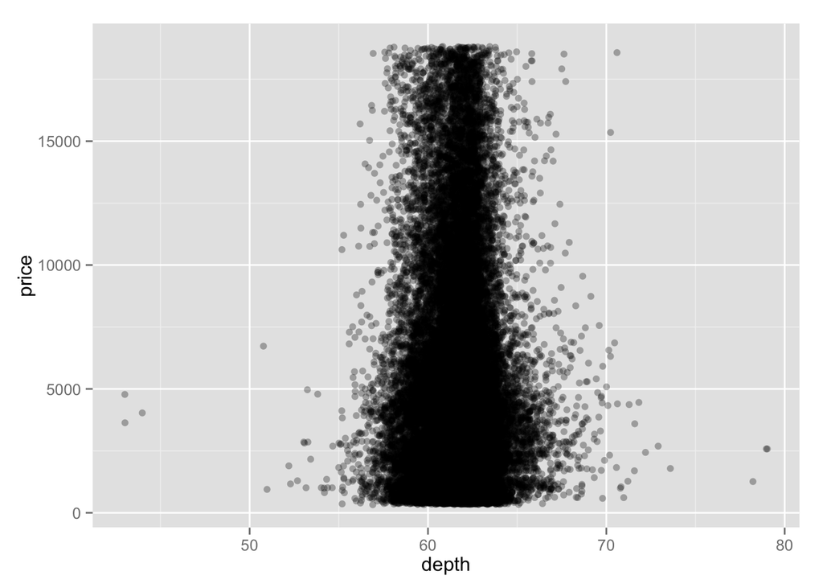

```r
ggplot(aes(x = depth, y = price), data = diamonds) +
  geom_jitter(alpha = 3/10)
```

### Overlapping of points

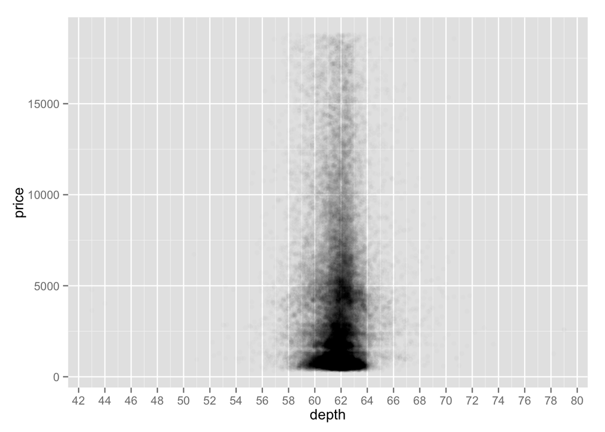

```r
# Change the code to make the transparency of the
# points to be 1/100 of what they are now and mark
# the x-axis every 2 units.

ggplot(data = diamonds, aes(x = depth, y = price)) +
  geom_point(alpha = 1/100) +
  scale_x_continuous(breaks = seq(0, 80, 2))
```

#### Based on the scatterplot of depth vs. price, most diamonds are betweeen what values of depth?

Response: lower limit to upper limit

59 to 65 59 to 64 ACCEPTED

```r
with(diamonds, cor.test(depth, price))
```

```
##
##  Pearson's product-moment correlation
##
## data:  depth and price
## t = -2.473, df = 53938, p-value = 0.0134
## alternative hypothesis: true correlation is not equal to 0
## 95 percent confidence interval:
##  -0.019084756 -0.002208537
## sample estimates:
##        cor
## -0.0106474
```

#### What is the correlation of depth vs. price

Response:

-0.010

#### Based on the correlation coefficient, would you use depth to predict the price of a diamond? and why?

Response:

No

much smaller than |0.3|

### price vs. carat

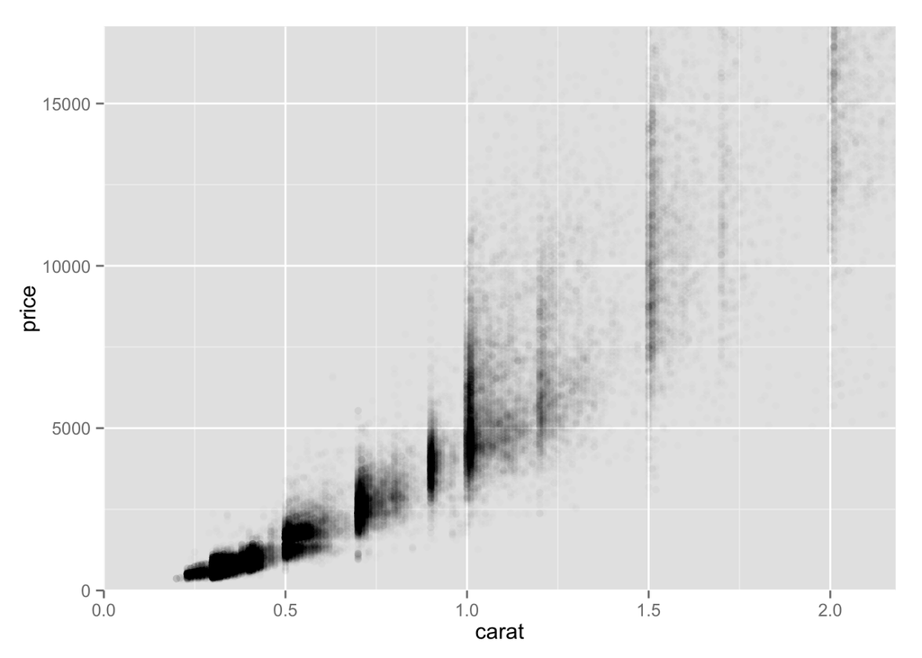

```r
# Create a scatterplot of price vs carat
# and omit the top 1% of price and carat
# values.

ggplot(data = diamonds, aes(x = carat, y = price)) +
  geom_point(alpha = 1/100) +
  coord_cartesian(xlim = c(0, quantile(diamonds$carat, 0.99)),
                  ylim = c(0, quantile(diamonds$price, 0.99)))
```

### price vs. volume

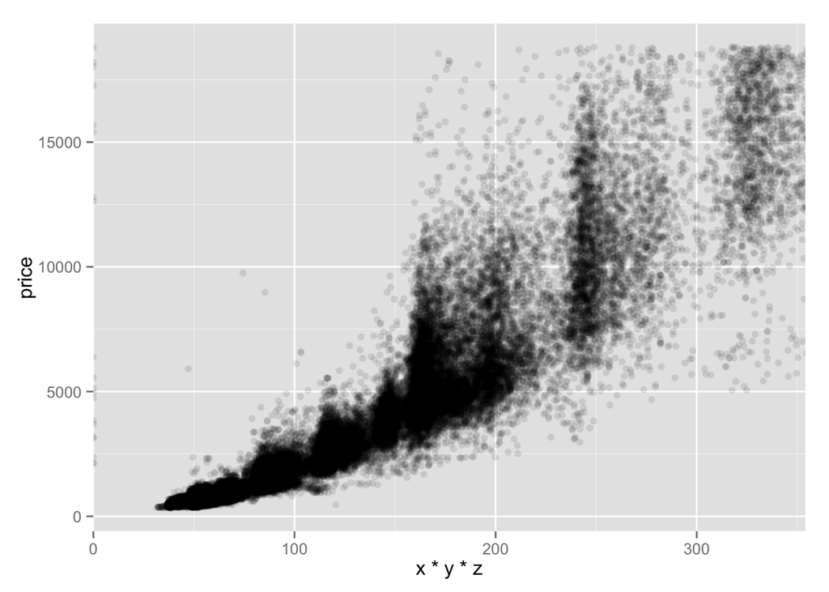

```r
# Create a scatterplot of price vs. volume (x * y * z).
# This is a very rough approximation for a diamond's volume.

# Create a new variable for volume in the diamonds data frame.
# This will be useful in a later exercise.

ggplot(data = diamonds, aes(x = x * y * z, y = price)) +
  geom_point(alpha = 1/10) +
  coord_trans(y="log10") +
  coord_cartesian(xlim = c(0, 354))
```

```r
# 354 is 99% bound of volume

diamonds$volume <- diamonds$x * diamonds$y * diamonds$z
```

#### What are your observations from the price vs. volume scatterplot?

Response:

some outliers. looks exponential. high upper range in bounding box at higher volumes

```r
with(subset(diamonds, (volume != 0) & (volume < 800)) ,
            cor.test(price, volume))
```

```
##
##  Pearson's product-moment correlation
##
## data:  price and volume
## t = 559.19, df = 53915, p-value < 2.2e-16
## alternative hypothesis: true correlation is not equal to 0
## 95 percent confidence interval:
##  0.9222944 0.9247772
## sample estimates:
##       cor
## 0.9235455
```

#### What is the correlation of price and volume?

Exclude diamonds that ahve a volume of 0 or that are greater than or equal to 800.

Response:

0.92

### Adjustments - price vs. volume

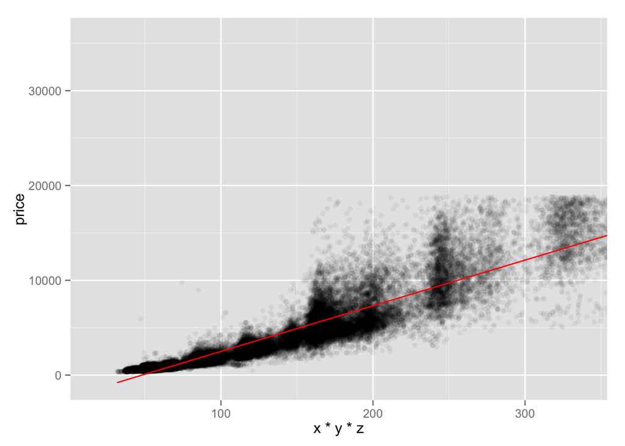

```r
# Subset the data to exclude diamonds with a volume
# greater than or equal to 800. Also, exclude diamonds
# with a volume of 0. Adjust the transparency of the
# points and add a linear model to the plot. (See the
# Instructor Notes or look up the documentation of
# geom_smooth() for more details about smoothers.)

# We encourage you to think about this next question and
# to post your thoughts in the discussion section.

# Do you think this would be a useful model to estimate
# the price of diamonds? Why or why not?

ggplot(data = subset(diamonds, (volume != 0) & (volume < 800)),
       aes(x = x * y * z, y = price)) +
  geom_point(alpha = 1/20) +
  stat_smooth(method = "lm", color = "red") +
  coord_cartesian(xlim = c(1, 354))
```

```r
# probably move away from a linear model, since data looks to be more exponential
```

### Mean Price by Clarity

```r
# Use the function dplyr package
# to create a new data frame containing
# info on diamonds by clarity.

# Name the data frame diamondsByClarity

# The data frame should contain the following
# variables in this order.

#       (1) mean_price
#       (2) median_price
#       (3) min_price
#       (4) max_price
#       (5) n

# where n is the number of diamonds in each
# level of clarity.
suppressMessages(library(ggplot2))
suppressMessages(library(dplyr))
data(diamonds)

diamondsByClarity <- diamonds %.%
  group_by(clarity) %.%
  summarise(mean_price = mean(price),
            median_price = median(price),
            min_price = min(price),
            max_price = max(price),
            n = n()) %.%
   arrange(clarity)
```

### Bar Charts of Mean Price

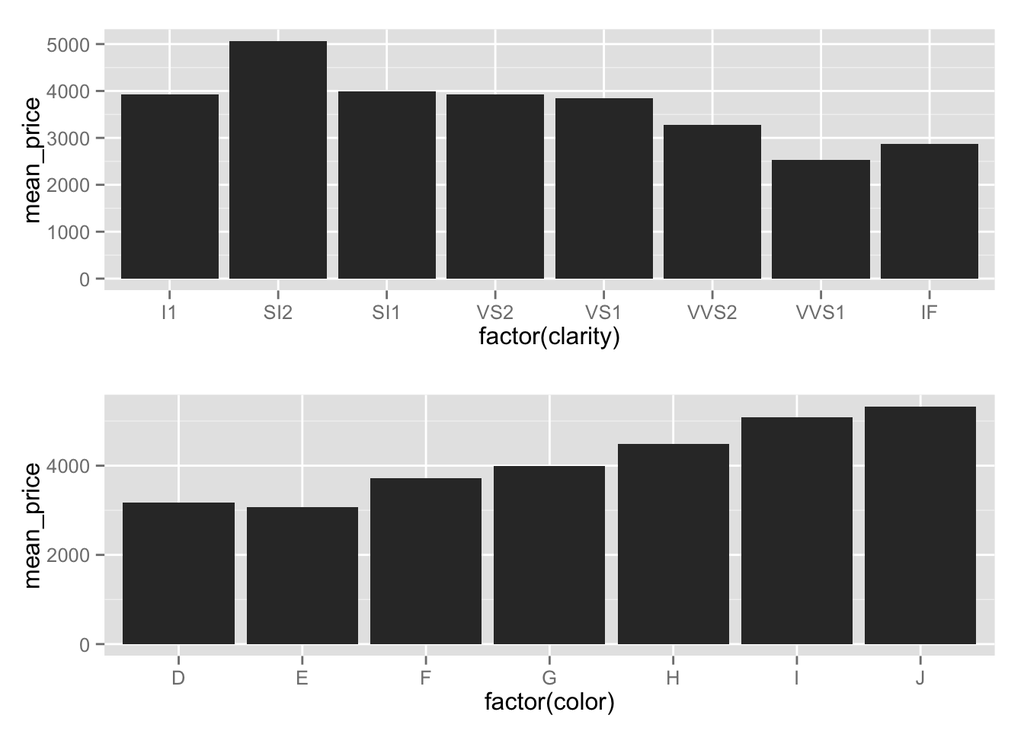

```r
# We’ve created summary data frames with the mean price
# by clarity and color. You can run the code in R to
# verify what data is in the variables diamonds_mp_by_clarity
# and diamonds_mp_by_color.

# Your task is to write additional code to create two bar plots
# on one output image using the grid.arrange() function from the package
# gridExtra.

data(diamonds)
library(dplyr)

diamonds_by_clarity <- group_by(diamonds, clarity)
diamonds_mp_by_clarity <- summarise(diamonds_by_clarity, mean_price = mean(price))

diamonds_by_color <- group_by(diamonds, color)
diamonds_mp_by_color <- summarise(diamonds_by_color, mean_price = mean(price))

# ENTER YOUR CODE BELOW THIS LINE
# ===================================================================
library(gridExtra)

p1 = ggplot(data = diamonds_mp_by_clarity,
       aes(x = factor(clarity), y = mean_price)) +
  geom_bar(stat = "identity")

p2 = ggplot(data = diamonds_mp_by_color,
       aes(x = factor(color), y = mean_price)) +
  geom_bar(stat = "identity")

grid.arrange(p1, p2, ncol = 1)
```

#### What did you notice in each of the bar charts for mean price by clarity and mean price by color?

Response:

mean price by clarity:

no discernable linear relation. a few of the factors had lower than across-the-board average, while one (SI2) had an outlier higher mean_price

mean price by color:

increasing price by factor color